# Workshop 6 - ANOVA: Comparing Three or More Groups in Jamovi

Research Methods and Statistics - T2 2026

**Introduction**

Hey team! Last week you ran the three *t*-tests and interpreted each one with the same **four interpretation questions**. What do you do when there are **three or more** groups or conditions to compare and we can no longer use *t*-tests? This week we answer that question by using the **analysis of variance (ANOVA)**. In Lecture 14 we introduced ANOVA (or *F*-tests), and today you run the two versions you need in Jamovi (one-way and repeated measures), check the assumptions yourself, work out *which* groups differ with a post-hoc test, and interpret the results.

The four questions don’t change. Two small additions for ANOVA: there is now a **whole-test effect size** (η², “eta squared”) as well as Cohen’s *d* for each pair (as you will see an ANOVA uses *t*-tests), and there is an extra step, the **post-hoc test**.

**Significance**Is p < α for the overall F? Reject or fail to reject H₀? If yes, which pairs differ (post-hoc)?

**Confidence interval**For each pair, what range of differences is plausible? Does it include 0?

**Effect size**If significant, how *big*? η² for the whole ANOVA, Cohen's d for each pair

**Clinical meaning**Do the differences beat the smallest change that matters (the minimum clinically important difference [MCID])?

You can come back to this page any time you need a reminder of how to run an ANOVA in Jamovi.

**What you’ll do today**

- Choose between a one-way ANOVA, a repeated measures ANOVA (and know when our data/study would require a *t*-test or a two-way ANOVA instead)
- Check normality, homogeneity of variance (Levene’s) and, for repeated measures ANOVA, sphericity (Mauchly’s)
- Run a one-way ANOVA and a repeated measures ANOVA and read the ANOVA table: SS, df, MS, F, p and η²
- Run Tukey post-hoc comparisons, read the mean differences, and calculate a 95% CI for a difference by hand
- See why running three *t*-tests are not the same as one ANOVA (the issue of multiple comparisons)
- Write up one result of each type using the four interpretation questions
- At home: find the interpretation mistakes in two ANOVA write-ups

[figure not shown]

**A real-world example…** a physiotherapist might use a **one-way ANOVA** to compare pain scores in patients randomised to manual therapy, dry needling or exercise prescription, a **repeated measures ANOVA** to compare the same participants’ blood glucose after three different breakfast types, and a **two-way ANOVA** to ask whether three stretching protocols improve flexibility differently in runners versus swimmers. A family of tests for three different types research designs, and (you guessed it) exactly what’s in this workshop, **minus the two-way**, which you will **only need to understand conceptually.**

## Why ANOVA, and not three *t*-tests?

ANOVA compares **means**, just like a *t*-test, but for **three or more** groups at once. It belongs on the same branch of the decision tree from the lecture, a *numeric outcome* with a *categorical predictor*, this time with more than two groups/levels.

| Question | Test | What it compares |
| --- | --- | --- |
| *Do three or more separate groups differ?* | **One-way ANOVA** | The means of *k* independent groups (between-subjects) |
| *Do the **same people** differ across three or more conditions or times?* | **Repeated measures (RM) ANOVA** | The means of *k* conditions measured in the same participants (within-subjects) |
| *Do two factors, and their combination, affect the outcome?* | **Two-way ANOVA** | Two main effects and their interaction (concept only in this course) |

**The F-test asks one question.** A significant ANOVA tells you *at least one* group mean differs from another. It does **not** tell you which, and it does **not** mean every group differs from every other. That’s what the **post-hoc test** is for, and you only get to that step and run it when the first overall tests’ (aka the omnibus test) F is significant.

## The ANOVA essentials

Work through these tabs before the tasks. They condense Lecture 14 (and the multiple-comparisons and effect-size ideas coming in Lecture 16) into what you need now and likely will help in the exam.

**Which test?**

Same two questions as last week, with one more level:

1. **How many groups/conditions?** Two → a *t*-test (independent or paired). Three or more → an ANOVA.
2. **Are the scores from the *same* people?** Yes → *repeated measures ANOVA*. No → *one-way ANOVA*.
3. **Is there a second factor** (e.g. training method *and* sex)? → *two-way ANOVA*. Again, we only need to know the concept, not the Jamovi/interpretation steps for this one.

| Design cue in the scenario | Test |
| --- | --- |
| “three groups”, “randomised to one of four diets”, “athletes, students and controls” | One-way ANOVA |
| “each participant tried all three”, “cross-over”, “baseline, 4 weeks and 8 weeks” | Repeated measures ANOVA |
| “does the effect of A depend on B”, two categorical predictors | Two-way ANOVA (interaction) |
| only two groups/conditions | *t*-test (an ANOVA on two groups gives the identical answer: F = t²) |

Quick-fire practice (no data needed):

Adults with high cholesterol are randomised to one of four diets (Mediterranean, low-fat, low-carb, usual diet) and LDL is measured after 12 weeks. Which test?

Independent samples t-test One-way ANOVA Repeated measures ANOVA Two-way ANOVA

**Hint:** how many groups? Is anyone measured more than once? Is there more than one categorical predictor?

Twenty asthma patients each use three different inhaler devices on separate days (order randomised) and peak expiratory flow is recorded after each. Which test?

Paired samples t-test One-way ANOVA Repeated measures ANOVA Two-way ANOVA

**Hint:** "each ... three ... on separate days" is the cross-over cue from last week, but now with three conditions instead of two.

A strength coach wants to know whether three training methods work equally well for male and female athletes, or whether the best method depends on sex. Which test?

Independent samples t-test One-way ANOVA Repeated measures ANOVA Two-way ANOVA

**Hint:** "depends on" is the interaction cue from the lecture's song-duration example (the lines on the plot weren't parallel).

Reaction time is compared between 30 regular gamers and 30 non-gamers. Which test?

Independent samples t-test One-way ANOVA Repeated measures ANOVA

**Hint:** count the groups. ANOVA is for three or more; with two, last week's test is the natural choice.

**The five steps**

With the F-statistic in step 3 and a sixth “which groups?” step tacked on the end. Jamovi does steps 3 and 4 (and the post-hoc arithmetic); steps 1, 2 and 5 are **yours**.

| Step | What you do | Where it happens today |
| --- | --- | --- |
| 1. **Assumptions** | Continuous outcome, independent people, approximately normal in each group, similar spread in each group (RM: plus sphericity) | Exploration ▸ Descriptives and the ANOVA dialog’s *Assumption Checks* |
| 2. **Hypotheses** | H₀: μ₁ = μ₂ = μ₃ (all group means equal). Hₐ: at least one mean differs | Written *before* you analyse |
| 3. **Test statistic** | F = MS<sub>between</sub> ÷ MS<sub>within</sub>, i.e. how far apart the group means are, relative to how scattered people are within groups | Jamovi ANOVA table, `F` |
| 4a. **p-value** | Probability of an F at least this large *if H₀ were true*, from the F-distribution with df₁ and df₂ | Jamovi ANOVA table, `p` |
| 4b. **Post-hoc** (if significant) | *Only if p < 0.05*: which pairs differ? Mean difference, CI, Cohen’s d, MCID for each pair | Jamovi *Post Hoc Tests* table |
| 5. **Conclusion** | Reject / fail to reject H₀, then interpret with η² and context | Your write-up |

**Degrees of freedom.** F has two: **df₁ = k − 1** (the number of groups minus one) and **df₂ = N − k** (the total number of people minus the number of groups) for a one-way ANOVA. For a repeated measures ANOVA the second one becomes **df₂ = (n − 1)(k − 1)** because the same n people are measured k times. Jamovi prints both in the ANOVA table and you report them as F(df₁, df₂).

**One tail, always.** F is a ratio of two variances and variances can’t be negative, so the whole of α = 0.05 sits in the right-hand tail. There is no one- vs two-tailed choice to make. Under H₀, F is usually around 1; a large F means the means are further apart than the within-group scatter can explain.

**Assumptions**

ANOVA is **parametric**, like the *t*-test, with one extra check for independent groups and another for repeated measures:

Check

What to look for

Jamovi

Shapiro–Wilk p > 0.05, bell-shaped histogram, Q-Q dots on the diagonal

Descriptives with *Split by*, or ANOVA ▸ Assumption Checks ▸ Normality test + Q-Q (one test on the *residuals* from all groups)

Levene’s p > 0.05. If violated, tick *Don’t assume equal (Welch’s)* correction and report that row

ANOVA ▸ Assumption Checks ▸ Homogeneity test

RM ANOVA ▸ Assumption Checks ▸ Sphericity tests

Plus the two you check from the **design** that the outcome is **continuous**, and observations are **independent** (one row = one person for a one-way ANOVA; for an RM ANOVA the three scores *within* a person are meant to be related, but each person must be independent of every other person i.e., no double ups).

**What is sphericity?** In a paired *t*-test we analysed one column of *difference scores*. With three conditions there are three sets of differences (A − B, A − C, B − C). Sphericity means those three sets of differences have roughly **equal variances**. If they don’t, the F-test is too liberal (more Type I errors), and the Greenhouse–Geisser correction fixes that by shrinking the degrees of freedom. We check it with Mauchly’s test. This explaination is for those wanting to know what is going on with these corrections and we won’t go into the correction’s maths in this course.

**Three traps when checking assumptions.** **(1)** Shapiro–Wilk in the ANOVA dialog is one test on the *residuals* (every score minus its own group mean), so a single p-value covers all groups; so we still look at the per-group plots from Descriptives. **(2)** Levene’s is “the assumption is fine” when p is *large*; a significant Levene’s is bad news, not good. ANOVA copes well with mildly unequal SDs when group sizes are equal (as they are today). **(3)** Outliers in a boxplot are not a reason to delete data. Remove a point only if you can justify it (a known measurement or entry error) and report that you did.

You’ll also see *Kruskal–Wallis* (under One-Way ANOVA ▸ Non-Parametric) and *Friedman* options in Jamovi. These are the **non-parametric** versions for when normality clearly fails; they’re not covered in this course, so leave them alone.

**Reading the output**

Jamovi’s ANOVA table has the pieces of the F-ratio laid out, one row for the factor and one for the error (“Residuals”):

| Column | Plain-English meaning |
| --- | --- |
| **Sum of Squares (SS)** | The raw variability. Factor row = how far the group means sit from the grand mean (between). Residuals row = how far individuals sit from their own group mean (within) |
| **df** | k − 1 for the factor; N − k for the residuals (RM: (n − 1)(k − 1)) |
| **Mean Square (MS)** | SS ÷ df, i.e. the variability *per degree of freedom*. This is what gets compared |
| **F** | MS<sub>between</sub> ÷ MS<sub>within</sub>. Bigger the value = stronger evidence against H₀ |
| **p** | Right-tail probability of an F this large if H₀ were true. Below 0.05 then it is *statistically significant* |
| **η²** | SS<sub>between</sub> ÷ SS<sub>total</sub>: the proportion of all the variability in scores that is explained by which group you are in (an effect size; tick it under *Effect Size*) |

The **Post Hoc Comparisons** table then has one row per pair, with columns you already know from the *t*-test: **Mean Difference**, **SE**, **df**, **t**, and **p<sub>tukey</sub>** (a p-value already corrected for the number of comparisons, so judge it against 0.05 as usual). For a one-way ANOVA you can also tick **Cohen’s d** for each pair. What Jamovi does *not* print is a 95% CI for each mean difference, so today we calculate it by hand, once, from mean difference (MD) and standard error (SE) (next tab).

**Two easy-to-confuse tables.** The *Descriptives* table (and the Estimated Marginal Means plot) shows each **group’s mean with its own 95% CI**. The *Post Hoc* table shows the **difference between two groups**. Only the second answers “do these two groups differ?”, and as you saw last week, two group CIs can overlap while the difference is still significant.

**Post-hoc & CIs**

**Why a post-hoc test and not three t-tests?** A significant F says at least one mean differs. To find out *which*, Jamovi runs a *t*-test on every pair, but with a correction that keeps the family-wise error rate at 5%. We use **Tukey’s HSD** (honestly significant difference), the standard choice when you want every pair compared. Bonferroni is the other common one; it just divides α by the number of tests. Both are already built into the p<sub>tukey</sub> / p<sub>bonferroni</sub> column, so never correct them again yourself.

**The 95% CI for a pairwise difference.** Same recipe as Week 5:

$$\text{95\% CI} = \text{Mean Difference} \pm (\text{critical value} \times SE)$$

The one wrinkle, because Tukey has made the test stricter, the matching interval uses a slightly bigger multiplier than the ordinary t-table value, so that the CI and p<sub>tukey</sub> always agree (i.e., CI excludes 0 then p<sub>tukey</sub> < 0.05). We give you the multiplier; you don’t need to look it up:

| Design today | df | t-table value | Tukey adjusted t-value |
| --- | --- | --- | --- |
| Task 1: one-way, N = 45, k = 3 | 42 | 2.02 | **2.43** |
| Task 2: RM, n = 25, k = 3 | 24 | 2.06 | **2.50** |

If you used the t-table value you would get a slightly narrower “unadjusted” interval, correct for a single planned comparison but not for three at once.

**Read the interval twice.** Once against **0** (is the difference statistically real?) and once against the **MCID** (is the whole interval, part of it, or none of it beyond the smallest difference that matters?). Lecture 16 will go deeper on this; today try and do it for every pair.

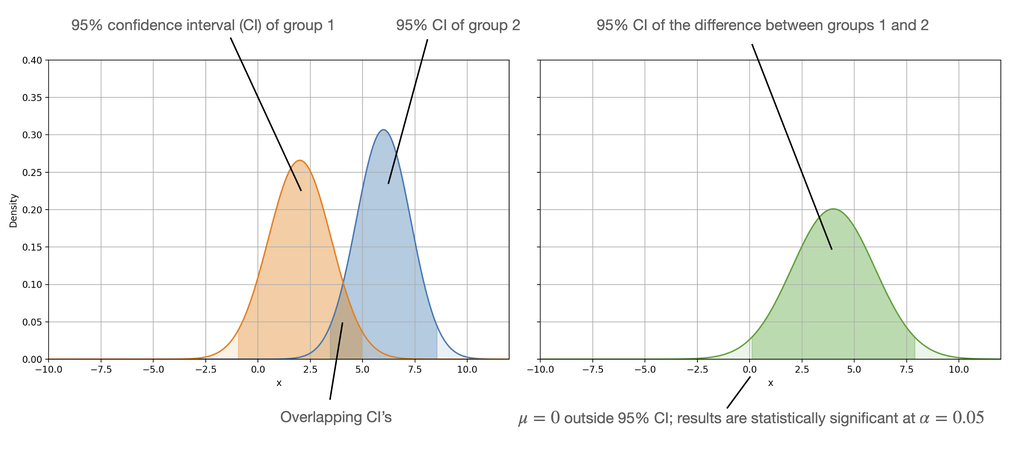

Left: the 95% CIs of two group means overlap. Right: the 95% CI of the *difference* between those same groups excludes 0, so the difference is significant. Same lesson as last week, and it comes up again in Task 1.

**Effect size**

Two effect sizes today, one you (should) know and one that’s new:

**Cohen’s *d* for each pair** (one-way ANOVA post-hoc). Exactly last week’s *d*: the mean difference in standard-deviation units (Jamovi uses the pooled within-group SD, √MS<sub>within</sub>). 0.2 small, 0.5 medium, 0.8 large. Jamovi doesn’t print *d* for repeated measures post-hoc pairs, so there we judge size from the mean difference against the scale and the MCID.

**η² (“eta squared”) for the whole ANOVA.** A *proportion* of how much of the total variability in the scores is explained by which group people are in.

$$\eta^2 = \frac{SS_{between}}{SS_{total}} = \frac{SS_{between}}{SS_{between} + SS_{within}}$$

They are **not** read the same way, so keep the two side by side:

|  | Cohen’s *d* | η² |
| --- | --- | --- |
| **What it is** | A *distance*, how far apart two means are | A *proportion*, how much of the variance the factor explains |
| **Units** | Standard deviations | A fraction of 1 (read it as a %) |
| **Applies to** | One pair of groups | The whole ANOVA (all groups at once) |
| **Small / medium / large** | 0.2 / 0.5 / 0.8 | 0.01 / 0.06 / 0.14 |
| **Say it as** | “the means are 0.89 SD apart” | “recovery method explains 69% of the variability” |
| **Never say** | “explains 89% of the variance” | “the groups are 0.69 SD apart” or “69% chance they differ” |

You don’t need the η² benchmarks by heart, but you should be able to *read* η² = 0.30 as “30% of the variation in the outcome is down to the factor”. Like *d*, η² is standardised, so it lets you compare an ANOVA on Task 1 heart RMSSD with Task 2 symptom scores. If it helps, η² is the same idea as *r*² from the correlation weeks i.e., it’s the proportion of variance explained, just with a categorical predictor.

Two effect size rules, unchanged from last week. **1)** If the overall p > 0.05, don’t interpret η² or run post-hoc tests, there is no difference to describe the size of. **2)** Effect size ≠ clinical meaningfulness. A “large” *d* between two recovery methods can still be a difference too small for an athlete to notice; the MCID decides that, not *d*.

## Get the Jamovi data files

[figure not shown]

Two datasets, one for each type of ANOVA. Save them somewhere easy to find, then open each in Jamovi when its task comes up.

- Task 1: [**Recovery_HRV.csv**](https://lms.griffith.edu.au/courses/32192/files/9304106?wrap=1) — 45 athletes, `Recovery Method` (Ice Bath / Compression / Active Recovery) and `RMSSD (ms)`
- Task 2: [**Antihistamine_Delivery.csv**](https://lms.griffith.edu.au/courses/32192/files/9304108?wrap=1) — 25 patients, `Oral`, `Nasal` and `Eye` symptom-relief scores (0–100)

In each file, check the Variables tab first. The outcomes should be *Continuous*, `Recovery Method` should be *Nominal*, and `ID` should be *ID*. Jamovi guesses, and it often guesses wrong. Notice the two files are shaped differently: Task 1 is **long** (one row per athlete, a group column), Task 2 is **wide** (one row per patient, one column per condition).

## Research questions

> 1. Which recovery method leads to the best next-day **heart rate variability** (RMSSD) in athletes… ice bath, compression, or active recovery?
> 2. Which antihistamine delivery method (oral tablet, nasal spray or eye drops) gives hay fever patients the best **symptom relief**?

## Tasks for you to do

Work through these in Jamovi in order and **check your answers as you go**. Each task has small answer boxes, type (or select) what you found and press **✓ Check**. As usual, you get instant feedback, and a hint appears if you’re stuck after a couple of tries. The full **worked answer** for each task stays locked until you answer correctly (a *reveal* option appears after three attempts, so have a genuine go first).

### Task 1 — One-way ANOVA: which recovery method?

[figure not shown]

**Scenario.** You’re the team’s sports scientist, and the head coach comes to you after a tough training camp: “We’ve been using ice baths, compression sleeves and light spin sessions for recovery, but which one actually helps the players’ bodies bounce back faster?”

You run a study with 45 athletes. After a hard session each athlete is randomised to one of three recovery methods: an **ice bath** (10 °C immersion), **compression garments**, or **active recovery** (30 min easy cycling at 30% VO₂max). The next morning you measure resting heart rate variability as RMSSD.

**What is RMSSD?** Your heart doesn’t beat like a metronome, the gap between beats varies slightly from one to the next. RMSSD (the root mean square of successive R–R interval differences, in milliseconds) captures how much that gap fluctuates. A well-recovered athlete shows *more* beat-to-beat variation, because the parasympathetic “rest and digest” system is back in charge. A fatigued or stressed athlete shows *less*. Typical resting values in trained athletes run from roughly 40 to 100 ms, and each person’s normal differs, so it’s the change that matters more than the raw number.

**Reading the results.** Higher RMSSD means better recovery, so whichever method produces the highest group mean is the winner. But a difference only matters practically if it’s big enough. Sports science research treats a gap of about 8 ms *between* recovery methods as the smallest difference that meaningfully affects next-day readiness. A 2 ms advantage might be statistically significant in a large sample and still be of no use to the coach.

- **H₀:** μ<sub>Ice</sub> = μ<sub>Compression</sub> = μ<sub>Active</sub> (all three recovery methods give the same mean RMSSD)
- **Hₐ:** at least one recovery method differs

**a) Explore and check assumptions, per group.** Open `Recovery_HRV.csv` in Jamovi. **Exploration ▸ Descriptives**: put `RMSSD (ms)` in *Variables* and `Recovery Method` in **Split by**. Tick **Shapiro–Wilk** and **Confidence interval** (for the mean), and under *Plots* the **Density** (under Histogram), **Box plot** and **Q-Q**. Look at the three SDs, is the largest less than twice the smallest? That’s a rule of thumb to suggest if variance is about equal or not.

From your split Descriptives (two decimal places):

Mean RMSSD, Active Recovery:

SD, Active Recovery:

Mean RMSSD, Compression:

SD, Compression:

Mean RMSSD, Ice Bath:

SD, Ice Bath:

**Hint:** with `Recovery Method` in *Split by*, the Descriptives table has one row per group. Two decimal places is plenty. Largest SD (4.19) ÷ smallest (2.66) = 1.6, under the "twice" rule of thumb.

Assumption check locked. Answer correctly above to unlock it.

**NoteWorked answer — descriptives & assumptions**

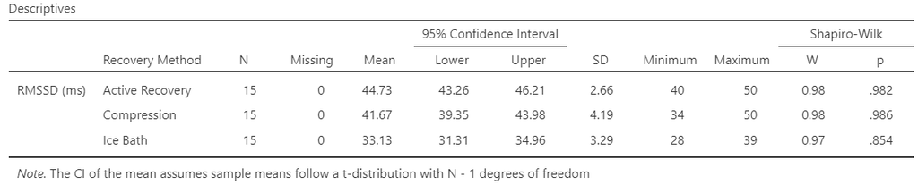

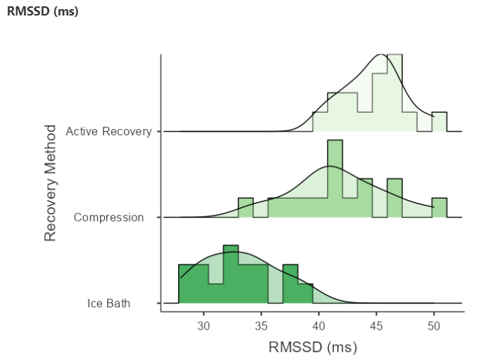

Density plots by group

Three roughly bell-shaped groups, there were no boxplot outliers, all three Shapiro–Wilk tests non-significant (p = 0.98, 0.99 and 0.85) therefore **Normality ✓** in each group. SDs 2.66, 4.19 and 3.29, the largest is 1.6 × the smallest, comfortably under the “less than twice” rule of thumb, so we expect Levene’s to pass (we’ll check it in the ANOVA dialog). Three separate groups of 15 athletes, each randomised to one method, so **independence ✓**.

Also notice the **95% CIs of the means**. Active Recovery [43.26, 46.21] and Compression [39.35, 43.98] **overlap**, while Ice Bath [31.31, 34.96] sits well below both. That should give us a clue for a significant difference, thought the overlapping group CIs do *not* settle whether Active and Compression differ.

Before you run the ANOVA, commit to three predictions from the descriptives alone (means 44.7 / 41.7 / 33.1 ms, SDs about 3 ms, n = 15 each). They are scored when you unlock the post-hoc worked answer.

1. Will the overall F-test be significant?

Yes No

2. Which pair will come closest to *not* being significant?

Active vs Compression Active vs Ice Bath Compression vs Ice Bath

3. Will the Active vs Compression difference beat the 8 ms threshold that matters?

Yes No

**b) Run the ANOVA.** **Analyses ▸ ANOVA ▸ ANOVA** (the general one, *not* “One-Way ANOVA”, which is missing the effect size and the plots we want):

[figure not shown]

1. Move `RMSSD (ms)` into **Dependent Variable** and `Recovery Method` into **Fixed Factors**
2. Under *Effect Size* tick **η²**
3. Under *Assumption Checks* tick **Homogeneity test**, **Normality test** and **Q-Q plot**
4. Under *Post Hoc Tests* move `Recovery Method` to the right-hand box; under *Correction* keep **Tukey** (untick “No correction”); under *Effect Size* tick **Cohen’s d**
5. Under *Estimated Marginal Means* move `Recovery Method` into **Term 1**, and tick **Marginal means plots** and **Marginal means tables**

From the ANOVA output:

Levene's test p:

Shapiro–Wilk test p:

Mean Square, Recovery Method:

Mean Square, Residuals:

F:

df for Residuals (df₂):

η²:

**Hint:** Levene's is in the *Homogeneity of Variances Test* table and Shapiro–Wilk in the *Normality Test* table, both under Assumption Checks. In the ANOVA table, F = 541.96 ÷ 11.81; check it on a calculator. df₂ = N − k = 45 − 3.

Worked answer locked. Enter the ANOVA output correctly to unlock it.

**NoteWorked answer — assumptions & the F-test**

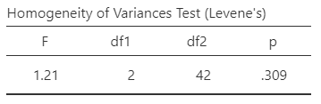

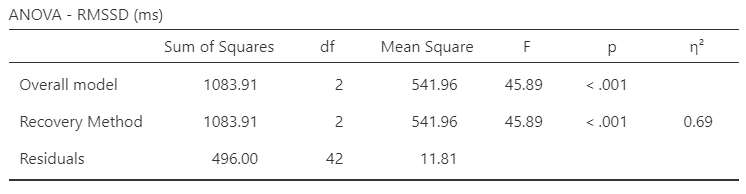

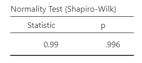

Normality test (residuals)

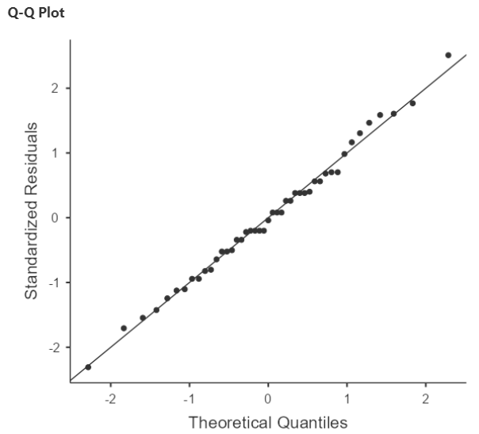

Q-Q plot of residuals

Build the interpretation of the overall test:

A one-way ANOVA compared next-day RMSSD across three recovery methods (n = 15 per group). Levene’s test was . There was a effect of recovery method, F(2, 42) = 45.89, p < 0.001, so we . η² = 0.69 means that , a effect. This result tells us that , so the next step is .

**Assumptions.** Levene’s F(2, 42) = 1.21, p = 0.309: no evidence the spreads differ, **homogeneity ✓**.

Shapiro–Wilk is non-signficant (p = 0.996) and the Q-Q dots hug the line, **normality ✓**.

**The F-ratio, by hand from the table.**

Between: SS = 1083.91 on df₁ = k − 1 = 2, so MS<sub>between</sub> = 541.96.

Within: SS = 496.00 on df₂ = N − k = 42, so MS<sub>within</sub> = 11.81.

F = 541.96 ÷ 11.81 = **45.89**.

rom an F-table the critical value at α = 0.05 is about 3.22 (the table’s nearest row, df₂ = 40, gives 3.23), so 45.89 is enormous by comparison, and Jamovi confirms with a p < 0.001.

The between-group variability is about 46 times the within-group variability (per degree of freedom); chance alone gives an F near 1.

**Effect size.** η² = 1083.91 ÷ (1083.91 + 496.00) = **0.686**. Recovery method accounts for roughly 69% of the variation in next-day RMSSD, a very large effect (≥ 0.14 is “large”).

**So far,** we can reject H₀ and say *at least one* method differs. We can’t yet say which, or by how much. Post-hoc test is next.

Model sentence locked. Complete the interpretation correctly to unlock it.

**NoteModel sentence so far — the overall F-test**

> A one-way ANOVA showed a significant effect of recovery method on next-day RMSSD, F(2, 42) = 45.89, p < 0.001, η² = 0.69 (recovery method explained about 69% of the variance). Tukey post-hoc comparisons were used to identify which methods differed.

**c) Which methods differ? The post-hoc test.** Scroll to the *Post Hoc Comparisons* table and the *Estimated Marginal Means* plot. Each row is one pair. Jamovi gives you the mean difference, its SE, t, the Tukey-corrected p and Cohen’s d, but not a CI, so you’ll calculate one.

From the Post Hoc Comparisons table (Tukey). Enter mean differences as positive numbers:

Active − Compression, mean difference:

Active − Compression, p<sub>tukey</sub>:

Active − Compression, Cohen's d:

Active − Ice Bath, mean difference:

Compression − Ice Bath, mean difference:

**Hint:** the sign of a difference just depends on which group Jamovi lists first. All three SEs are the same (1.25) because a one-way ANOVA uses the pooled within-group variance (MS<sub>within</sub>) for every pair and the groups are the same size.

Worked answer locked. Enter the post-hoc output correctly to unlock it.

**NoteWorked answer — post-hoc comparisons**

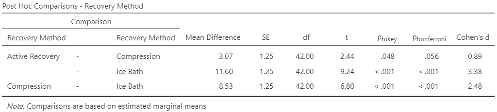

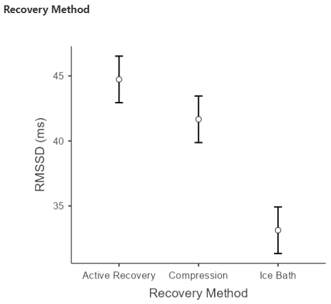

Now the four interpretation questions.

**Significance.** All three Tukey comparisons are significant.

Active vs Compression p = 0.048 (a whisker under 0.05).

Active vs Ice Bath and Compression vs Ice Bath both p < 0.001. So *every* method differs from every other, statistically.

**Confidence intervals** MD ± 2.43 × 1.25 = MD ± 3.04.

Active − Compression MD = 3.07 [0.03, 6.11]: just excludes 0, matching p = 0.048, but the plausible difference runs from almost nothing up to 6 ms.

Active − Ice Bath MD = 11.60 [8.56, 14.64] and Compression − Ice Bath MD = 8.53 [5.49, 11.57] are well clear of 0.

**Effect size.** d = 0.89, 3.38 and 2.48

All “large” by Cohen’s benchmarks. That’s what a very tight within-group spread (SD ≈ 3.4 ms) does; even a 3 ms gap is nearly a whole SD. Remember d is the gap between groups in SD units, not in ms.

**Clinical meaning.** Against the 8 ms threshold

Active vs Compression (3.07 ms; upper CI limit 6.11) is **not meaningful**, statistically “large” or not.

Active vs Ice Bath (11.60 ms, CI 8.56 to 14.64) is **clearly meaningful**, every plausible value is beyond the threshold.

Compression vs Ice Bath (8.53 ms) is beyond the threshold on average, but its CI (5.49 to 11.57) straddles 8 ms, so call it **probably meaningful**. A bigger study would be able pin it down. Either way the ice bath left athletes **less recovered** the next morning.

The honest advice to the coach, active recovery or compression, take your pick on cost and logistics, and rethink the ice baths for next-day HRV.

**The overlapping-CI lesson, again.** In the marginal-means plot the Active and Compression error bars overlap, yet their difference is significant. Overlapping *group* CIs never rule out a significant *difference*. Non-overlapping *group* CIs can predict a significant *difference* though.

**By hand, calculate the 95% CI** for the closest pair, Active Recovery vs Compression:

95% CI = MD ± 2.43 × SE

The 2.43 is the Tukey multiplier for df = 42 described in the *Post-hoc & CIs* tab at the start of this worksheet in The ANOVA essentials. It has been adjusted to account for multiple comparisons in the ANOVA. SE = SEM in the course I call it SE0 or SEp when talking about proportions, or SEM when the standard error of a mean. Jamovi just calls it SE.

95% CI for the Active − Compression difference, to 2 decimal places:

Lower limit:

Upper limit:

**Hint:** margin = 2.43 × 1.25 = 3.04. Subtract it from and add it to 3.07.

Build the interpretation for the Active Recovery vs Compression pair:

Active recovery produced higher RMSSD than compression by 3.07 ms, a difference that was (p<sub>tukey</sub> = 0.048). The 95% CI [0.03, 6.11] , which the p-value. Cohen’s d = 0.89 is a effect by Cohen’s benchmarks. However, the mean difference, and even the upper limit of its CI, is the 8 ms threshold that matters for athletes, so the difference is . The two group CIs in the marginal-means plot overlap, which .

**Hint:** p = 0.048 is under 0.05 by a whisker and the CI’s lower limit of 0.03 says the same thing. Compare 6.11 (the most optimistic end of the CI) with 8 ms. And re-read the overlapping-CI warning in the essentials.

Model write-up locked. Complete the interpretation correctly to unlock it.

**NoteModel write-up — Task 1**

> A one-way ANOVA showed a significant effect of recovery method on next-day RMSSD, F(2, 42) = 45.89, p < 0.001, η² = 0.69. Tukey post-hoc comparisons showed that RMSSD was higher after active recovery (x = 44.7, SD = 2.7 ms) than after compression (x = 41.7, SD = 4.2; MD = 3.07 ms, 95% CI [0.03, 6.11], p = 0.048, d = 0.89), and both were higher than after an ice bath (x = 33.1, SD = 3.3; MD = 11.60 and 8.53 ms respectively, both p < 0.001, d = 3.38 and 2.48). Only the ice-bath comparisons reached the 8 ms threshold considered meaningful for recovery (clearly for active recovery vs ice bath, 95% CI [8.56, 14.64]; on average for compression vs ice bath, 95% CI [5.49, 11.57]); the 3 ms advantage of active recovery over compression, although statistically significant, is unlikely to matter in practice.

**Sort the pairs.** Read each card’s CI. Once against 0 and once against the 8 ms threshold, and drag it into the column that fits (or tap a card, then tap a column). One column will stay empty today.

Sort the three Tukey comparisons (MCID = 8 ms):

CIs use mean difference (MD) ± 2.43 × 1.25.

Active − CompressionMD 3.07 ms · 95% CI [0.03, 6.11] · p = 0.048

Active − Ice BathMD 11.60 ms · 95% CI [8.56, 14.64] · p < 0.001

Compression − Ice BathMD 8.53 ms · 95% CI [5.49, 11.57] · p < 0.001

**No evidence of a difference yet**CI includes 0 (p ≥ 0.05)

**Real, but too small to matter**CI excludes 0 but sits entirely below the MCID

**Real, might matter**CI excludes 0 and straddles the MCID; more data would settle it

**Clearly meaningful**whole CI beyond the MCID

**Hint:** a CI of [5.49, 11.57] contains 8, so a true difference just under 8 ms is still plausible; [8.56, 14.64] does not, so every plausible value is beyond the threshold; [0.03, 6.11] never reaches 8 at all.

**Clinical meaning.** The other two differences are Active − Ice Bath = 11.60 ms and Compression − Ice Bath = 8.53 ms, both p<sub>tukey</sub> < 0.001 with d = 3.38 and 2.48. Given the 8 ms threshold, what do you tell the coach?

Use active recovery only: it beat both other methods significantly, so it is the clear winner Use active recovery or compression, either is fine; drop the ice baths, which left RMSSD 8–12 ms lower The differences are all statistically significant, so all three methods are meaningfully different from each other

**Hint:** compare each mean difference with 8 ms. Active vs compression is 3.07 ms (below); both comparisons with ice bath are above. Significance says "real", the threshold says "matters".

**Design check before Task 2.** Athletes were *randomised* to a recovery method, so this design can support a causal claim (the method caused the difference), unlike last week’s coffee study where students chose their own group. Task 2 goes one step further: the same patients try every treatment, which removes person-to-person differences from the comparison altogether. Watch what that does to the error term.

### Task 2 — Repeated measures ANOVA: antihistamine delivery

[figure not shown]

**Scenario.** You’re a clinical researcher at an allergy clinic, and the lead physician has a practical question *“We stock three antihistamine formulations, tablets, nasal sprays and eye drops. Patients always ask which works best for their hay fever, and honestly I don’t have solid data. Can we please find out?”* You run a **cross-over** study with 25 patients with moderate-to-severe allergic rhinitis. Each patient tries all three during separate pollen weeks, in randomised order with a washout in between. You use an **oral tablet** (cetirizine 10 mg), a **nasal spray** (azelastine 0.1%) and **eye drops** (olopatadine 0.2%). Two hours after each dose you score total symptom relief on a validated 0–100 scale (nasal congestion, sneezing, itchy eyes, runny nose combined; **higher = better**). From the allergy literature: a score of **≥ 70** means effective relief (normal daily activities), 50–69 partial relief, < 50 ineffective; and a difference of **8 points** between treatments is the smallest that patients can reliably notice.

- **H₀:** μ<sub>Oral</sub> = μ<sub>Nasal</sub> = μ<sub>Eye</sub> (all three deliveries give the same mean relief)
- **Hₐ:** at least one delivery method differs

**a) Explore and check normality, per condition.** Open `Antihistamine_Delivery.csv` in Jamovi. This file is **wide**: one row per patient, three columns. **Exploration ▸ Descriptives**: put `Oral`, `Nasal` and `Eye` all in *Variables* (nothing in Split by). Tick **Shapiro–Wilk** and **Confidence interval**, and under *Plots* the **Density**, **Box plot** and **Q-Q**. You’ll see a few boxplot outliers (one tablet score of 60, for instance); don’t remove them, there’s no reason to think they’re errors.

From your Descriptives:

Mean relief, Oral:

Mean relief, Nasal:

Mean relief, Eye:

SD, Oral:

Eye drops, relief category:

**Hint:** three rows in the Descriptives table, one per column. Compare each mean with the 70-point line in the scenario.

Assumption check locked. Answer correctly above to unlock it.

**NoteWorked answer — descriptives & normality**

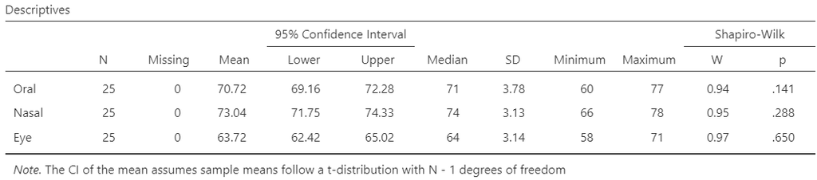

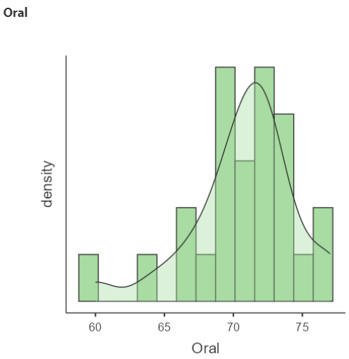

Oral

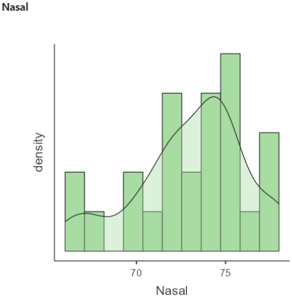

Nasal

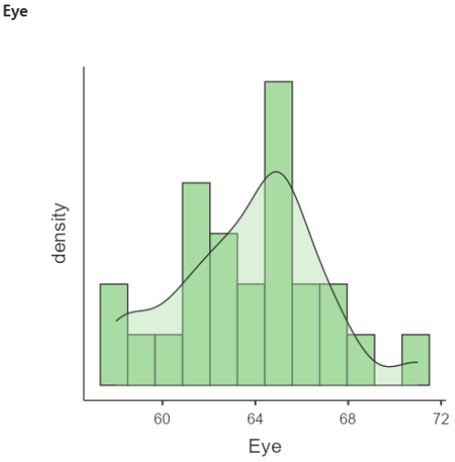

Eye

Nasal spray scores highest (73.0), tablets a little lower (70.7) and eye drops well below both (63.7), which already puts eye drops in the “partial relief” band while the other two clear 70. All three conditions are approximately normal (Shapiro–Wilk p = 0.14, 0.29 and 0.65; slightly lumpy density plots with n = 25 are normal). A handful of boxplot outliers (patient 4’s tablet score of 60, patient 18’s eye-drop score of 71) are real scores, so they stay. Each patient is independent of every other patient; the three scores *within* a patient are related by design, which is exactly what the RM ANOVA is for.

The three group CIs, [69.2, 72.3], [71.8, 74.3] and [62.4, 65.0]. Oral and Nasal overlap while Eye is nowhere near either.

Before you run the RM ANOVA, three predictions from the descriptives (means 70.7 / 73.0 / 63.7, SDs about 3.5, n = 25, each patient tried all three). Scored when you unlock the post-hoc worked answer.

1. Task 1 gave an large F = 45.89 with 45 athletes. So with only 25 patients here, would you expect F be larger or smaller?

Larger Smaller

2. Oral tablet and nasal spray are only 2.3 points apart, less than one SD. Would we expect that pair to be significant?

Yes No

3. Which pairs should have a mean difference above the 8-point threshold?

None of them Nasal vs Eye only Both comparisons with Eye drops All three

**b) Run the repeated measures ANOVA.** **Analyses ▸ ANOVA ▸ Repeated Measures ANOVA**:

[figure not shown]

1. In *Repeated Measures Factors* (top right), click `RM Factor 1` and rename it **Delivery Method**; rename the three levels (`Level 1`, `Level 2`, `Level 3`) to **Oral tablet**, **Nasal spray**, **Eye drops**
2. Under *Dependent Variable Label* (below the boxes), rename `Dependent` to **Symptom relief (0–100).** This labels the plot.
3. Drag `Oral`, `Nasal` and `Eye` into the three **Repeated Measures Cells**, in that order
4. Under *Effect Size* tick **η²**
5. Under *Assumption Checks* tick **Sphericity tests**, and under *Sphericity corrections* tick **None** and **Greenhouse–Geisser** (so you can see both rows); tick **Q-Q plot**
6. Under *Post Hoc Tests* move `Delivery Method` to the right; under *Correction* keep **Tukey**
7. Under *Estimated Marginal Means* move `Delivery Method` into **Term 1**, tick **Marginal means plots**, **Marginal means tables** and **Observed scores**

**What you’re checking with Mauchly’s.** Sphericity says the three sets of within-person differences (Oral − Nasal, Oral − Eye, Nasal − Eye) have similar variances. Here their SDs are 3.96, 4.97 and 4.45, similar enough. Mauchly’s p > 0.05 means “no evidence against sphericity”, read the **None** row of the ANOVA table. If Mauchly’s p were < 0.05 you’d read the **Greenhouse–Geisser** row instead (same F, smaller df, larger p).

From the RM ANOVA output:

Mauchly's W:

Mauchly's p:

df, Delivery Method (df₁):

df, Residual (df₂):

F (None / sphericity-assumed row):

η²:

**Hint:** Mauchly's is in the *Tests of Sphericity* table. In the *Within Subjects Effects* table, df₂ = (n − 1)(k − 1) = 24 × 2. If you ticked Greenhouse–Geisser you'll see two rows; use the "None" row because sphericity was met.

Worked answer locked. Enter the RM ANOVA output correctly to unlock it.

**NoteWorked answer — sphericity & the F-test**

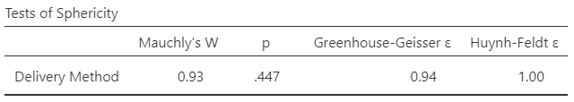

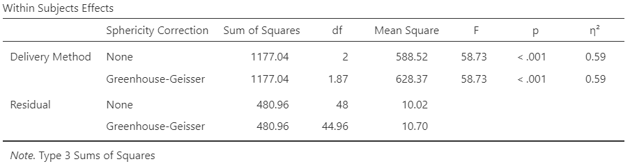

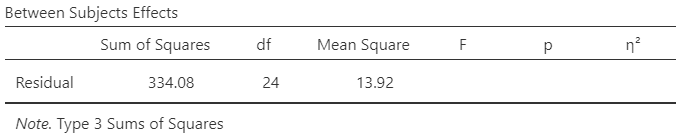

Between-subjects table

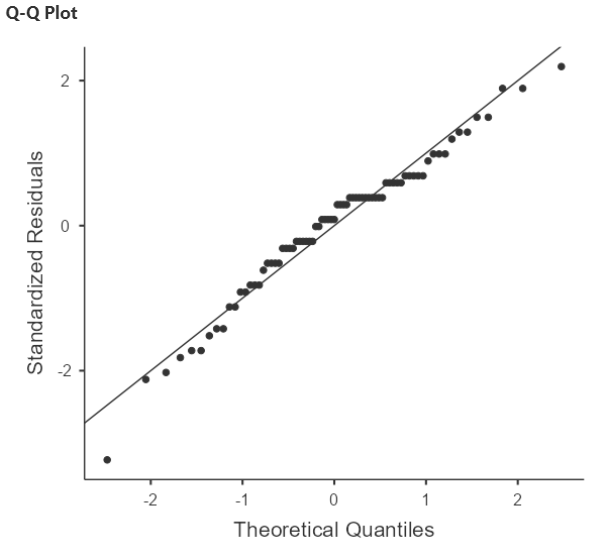

Q-Q plot of residuals

Build the interpretation of the overall test:

A repeated measures ANOVA compared symptom relief across three delivery methods in the same 25 patients. Mauchly’s test was . There was a effect of delivery method, F(2, 48) = 58.73, p < 0.001, so we . η² = 0.59 means that about . The second degrees-of-freedom value is 48 rather than Task 1’s 42 because .

**Hint:** for Mauchly's, like Levene's, a large p is good news. η² is a proportion of variance. Check the df rule in the "five steps" tab.

**Sphericity.** Mauchly’s W = 0.93, p = 0.447.

No evidence against sphericity, so read the uncorrected (“None”) row. (Greenhouse–Geisser ε = 0.94 would barely change the df anyway.)

**The F-ratio.**

Delivery Method: SS = 1177.04 on df₁ = 2, MS = 588.52.

Residual: SS = 480.96 on df₂ = (25 − 1)(3 − 1) = 48, MS = 10.02.

F = 588.52 ÷ 10.02 = **58.73**, p < 0.001 (F-table critical value for (2, 48) df ≈ 3.19).

Reject H₀: delivery method affects symptom relief.

**Effect size.** η² = 1177.04 ÷ (1177.04 + 480.96 + 334.08) = **0.59**.

Of all the variability in symptom scores across this study, 59% is accounted for by which formulation the patient was taking. The remaining 41% is everything else — day-to-day fluctuation, how badly each patient’s hay fever runs, measurement noise. The conventional benchmarks are 0.01 small, 0.06 medium and 0.14 large, so 0.59 is a very large effect. In plain terms: formulation isn’t a minor contributor here, it’s the dominant one. That’s the finding you’d take to a clinician. You should always report an effect size alongside your p value. Significance tells you an effect is there, effect size tells you whether anyone should care.

**So far:** at least one delivery method differs. Post-hoc test is needed.

Model sentence locked. Complete the interpretation correctly to unlock it.

**NoteModel sentence — the overall F-test**

> A repeated measures ANOVA showed a significant effect of delivery method on symptom relief, F(2, 48) = 58.73, p < 0.001, η² = 0.59 (Mauchly’s p = 0.447 so sphericity assumed). Tukey post-hoc comparisons were used to identify which methods differed.

**c) Which deliveries differ? The post-hoc test.** Scroll to *Post Hoc Comparisons – Delivery Method*. Jamovi reports MD, SE, df, t and p<sub>tukey</sub> for each pair, but for a repeated measures ANOVA it does not offer Cohen’s d, so we’ll judge size from the mean difference against the 8-point threshold.

From the Post Hoc Comparisons table (Tukey). Enter mean differences as positive numbers:

Oral − Nasal, mean difference:

Oral − Nasal, p<sub>tukey</sub>:

Oral − Eye, mean difference:

Oral − Eye, SE:

Nasal − Eye, mean difference:

**Hint:** three rows: Oral tablet − Nasal spray, Oral tablet − Eye drops, Nasal spray − Eye drops. A negative Oral − Nasal difference means the nasal spray scored higher.

Worked answer locked. Enter the post-hoc output correctly to unlock it.

**NoteWorked answer — post-hoc comparisons**

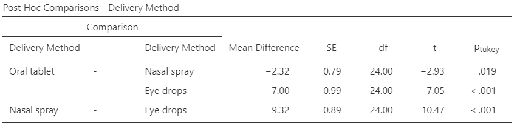

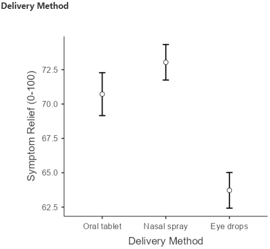

**Significance.** All three pairs differ.

Oral − Nasal p = 0.019

Oral − Eye p < 0.001

Nasal − Eye p < 0.001.

**Confidence intervals** MD ± 2.50 × SE (using each pair’s own SE)

Oral − Nasal: −2.32 ± 2.50 × 0.79 = MD −2.32 [−4.30, −0.34] (nasal higher; excludes 0, matching p = 0.019).

Oral − Eye: 7.00 ± 2.50 × 0.99 = MD 7.00 [4.52, 9.48].

Nasal − Eye: 9.32 ± 2.50 × 0.89 = MD 9.32 [7.10, 11.54].

All exclude 0, all agree with their p-values. For those interested, you might notice the SEs differ between pairs this time (0.79, 0.99, 0.89), because each pair is based on its own column of within-person differences, whereas Task 1 used one pooled within-group variance for every pair.

**Effect size.** Jamovi gives none for RM post-hoc pairs. If you want a rough d, divide the mean difference by the typical SD of the scores (about 3.5): 0.7, 2.0 and 2.7, medium-to-large and very large. The overall-test η² = 0.59 already tells you the effect is big.

**Clinical meaning.**

Nasal - tablet is 2.32 points on a scale where 8 is the smallest noticeable difference, and both means sit above the 70-point “effective” line: **not meaningful**, prescribe on preference, cost and side effects.

Tablet - Eye drops is 7.00 points with a CI from 4.5 to 9.5, so the true difference could be just under or just over the MCID threshold likely a **real, possibly meaningful, but more data needed**.

Spray - Eye drops is 9.32 points above the threshold on average [CI 7.1 to 11.5] so **practically** **meaningful**.

Add the fact that eye drops alone averaged 63.7, in the partial-relief band, and the advice is clear. Tablet or spray first-line for total symptom control, eye drops as an add-on for ocular symptoms, not on their own if wanting the most effective option.

**By hand, calculate the 95% CI** for Oral − Eye:

95% CI = MD ± 2.50 × SE

The 2.50 is the Tukey multiplier for df = 24 described in the *Post-hoc & CIs* tab at the start of this worksheet in The ANOVA essentials. It has been adjusted to account for multiple comparisons in the ANOVA. SE = SEM in the course I call it SE0 or SEp when talking about proportions, or SEM when the standard error of a mean. Jamovi just calls it SE.

95% CI for the Oral − Eye difference, to 2 decimal places:

Lower limit:

Upper limit:

**Hint:** margin = 2.50 × 0.99 = 2.48. Subtract it from and add it to 7.00.

Build the clinical interpretation across the three pairs:

All three pairwise differences were statistically significant. Nasal spray beat the oral tablet by 2.32 points (p = 0.019), but as this is the 8-point threshold and both means are , the two are . Eye drops scored 7.00 points below the tablet (95% CI [4.52, 9.48]) and 9.32 below the spray; the tablet comparison , while the spray comparison sits . Since eye drops alone also left patients in the , the recommendation is .

**Hint:** compare each mean difference (2.32, 7.00, 9.32) and its CI with 8 points, and each mean (70.7, 73.0, 63.7) with the 70-point line. Significance tells you the difference isn't zero; the thresholds tell you whether a patient would notice.

Model write-up locked. Complete the interpretation correctly to unlock it.

**NoteModel write-up — Task 2**

> A repeated measures ANOVA showed a significant effect of delivery method on symptom relief in 25 patients with allergic rhinitis, F(2, 48) = 58.73, p < 0.001, η² = 0.59 (sphericity assumed, Mauchly’s p = 0.447). Tukey post-hoc comparisons showed that relief was higher with the nasal spray (x = 73.0, SD = 3.1) than the oral tablet (x = 70.7, SD = 3.8; MD = 2.32, 95% CI [0.34, 4.30], p = 0.019), and that both were higher than eye drops (x = 63.7, SD = 3.1; MD = 9.32 [7.10, 11.54] and 7.00 [4.52, 9.48], both p < 0.001). Only the eye-drop comparisons approached or exceeded the 8-point minimal noticeable difference, and eye drops alone fell short of the 70-point threshold for effective relief, so a tablet or nasal spray is recommended as first-line treatment.

**Sort the pairs.** Same four columns as Task 1, now with the 8-point MCID. Read each CI against 0, then against 8.

Sort the three Tukey comparisons (MCID = 8 points):

CIs use MD ± 2.50 × SE, with each pair's own SE.

Nasal − OralMD 2.32 · 95% CI [0.34, 4.30] · p = 0.019

Oral − EyeMD 7.00 · 95% CI [4.52, 9.48] · p < 0.001

Nasal − EyeMD 9.32 · 95% CI [7.10, 11.54] · p < 0.001

**No evidence of a difference yet**CI includes 0 (p ≥ 0.05)

**Real, but too small to matter**CI excludes 0 but sits entirely below the MCID

**Real, might matter**CI excludes 0 and straddles the MCID; more data would settle it

**Clearly meaningful**whole CI beyond the MCID

**Hint:** does the interval contain 8? [4.52, 9.48] and [7.10, 11.54] both do, one from below on average and one from above. [0.34, 4.30] never gets near it.

### Task 3 — Under the bonnet: where F comes from (if we have time in class)

No Jamovi needed.

Try these in order:

You press *Same means, wider spread*. So the variablity (spread) of the data points around their mean get larger. Which sum of squares changes, and what happens to F?

SS<sub>between</sub> increases, so F increases SS<sub>within</sub> increases, SS<sub>between</sub> stays the same, so F decreases Both increase in proportion, so F is unchanged

**Hint:** read the two SS cards before and after pressing the preset. F = MS<sub>between</sub> ÷ MS<sub>within</sub>: what happens to a ratio when only the bottom grows?

**b) By hand, once.** The exam gives you sums of squares and asks for the F-test with an F-table, exactly like the sprint-training example in Lecture 14. Do it once here for the Task 1 data:

SS<sub>between</sub> = 1083.91, SS<sub>within</sub> = 496.00, k = 3 groups, N = 45 athletes.

Fill in the F-ratio (two decimal places):

df₁ = k − 1:

df₂ = N − k:

MS<sub>between</sub> = SS ÷ df₁:

MS<sub>within</sub> = SS ÷ df₂:

F = MS<sub>between</sub> ÷ MS<sub>within</sub>:

**Hint:** 1083.91 ÷ 2 and 496.00 ÷ 42, then divide one by the other.

Worked answer locked. Answer correctly above to unlock it.

**NoteWorked answer — F by hand**

df₁ = 3 − 1 = 2

df₂ = 45 − 3 = 42.

MS<sub>between</sub> = 1083.91 ÷ 2 = 541.96

MS<sub>within</sub> = 496.00 ÷ 42 = 11.81

F = 541.96 ÷ 11.81 = **45.89**

Critical F ≈ 3.22 (table row (2, 40): 3.23) < 45.89, so reject H₀ at α = 0.05 (p < 0.05).

**Conclusion in words:** There is significant evidence (F = 45.89, p < 0.05) that at least one recovery method produces a different mean next-day RMSSD. Which is/are not known needs a post-hoc test.

### Task 4 — Spot the error (do at home)

Two short results paragraphs, written the way a rushed student (or a rushed paper) might write them. Each contains mistakes of the kind in the *six traps* list further down. **Click every sentence you think is wrong**, then press Check. Get them all and the explanations appear under each one.

**Write-up 1: one-way ANOVA.** A trial compared hamstring flexibility (sit-and-reach, cm) after six weeks of static stretching (n = 20), PNF stretching (n = 20) or foam rolling (n = 20). Jamovi gave: Levene’s p = 0.62; F(2, 57) = 3.42, p = 0.040, η² = 0.107; Tukey: PNF − Static MD = 3.1 cm, p = 0.031, d = 0.72; PNF − Foam MD = 2.4 cm, p = 0.11, d = 0.55; Static − Foam MD = −0.7 cm, p = 0.86, d = 0.16. The smallest change in sit-and-reach that matters is about 2.5 cm.

Find the four sentences that contain an error:

8 sentences, 4 errors.

A one-way ANOVA showed a significant effect of protocol on flexibility, F(2, 57) = 3.42, p = 0.040. η² = 0.107, meaning the protocols differed by about 11% on average. Levene's test was significant (p = 0.62), so equal variances could be assumed. Because the ANOVA was significant, all three protocols differ from each other. Tukey post-hoc tests showed PNF improved flexibility more than static stretching (MD = 3.1 cm, p = 0.031, d = 0.72, a medium-to-large effect). PNF also outperformed foam rolling (MD = 2.4 cm, d = 0.55, a medium effect), although this did not reach significance (p = 0.11). Given a minimal clinically important difference of about 2.5 cm, the 3.1 cm advantage of PNF over static stretching is likely to be meaningful for athletes. The overall Type I error rate was kept at 5% by using Tukey's correction rather than three separate t-tests.

**Hint:** check every claim against the numbers given: what does η² measure? Is 0.62 significant? Which pairs are actually p < 0.05? Can you interpret d when p > 0.05?

**Write-up 2: repeated measures ANOVA.** Twenty runners completed a 10-km time trial in three shoe conditions (conventional A, conventional B, carbon-plate), in randomised order a week apart. Jamovi gave: Mauchly’s W = 0.78, p = 0.02; F = 6.10, p = 0.004 (uncorrected row), η² = 0.24; Tukey: carbon-plate faster than A by 45 s (95% CI 31 to 59 s) and than B by 38 s (95% CI 33 to 43 s), both p < 0.01; A vs B p = 0.61. A 30-s change is the smallest that matters over 10 km.

Find the two sentences that contain an error:

7 sentences, 2 errors.

A repeated measures ANOVA compared 10-km time-trial performance across three shoe conditions in the same 20 runners. Mauchly's test was significant (p = 0.02), so sphericity was assumed and the uncorrected row was reported. There was a significant effect of shoe, F(2, 57) = 6.10, p = 0.004. η² = 0.24, so shoe condition explained about a quarter of the variability in time-trial performance. Because each runner served as their own control, between-runner differences in fitness were removed from the error term, increasing power. Tukey comparisons showed the carbon-plate shoe was faster than both conventional shoes (by 45 s and 38 s, both p < 0.01), while the two conventional shoes did not differ (p = 0.61). Since a 30-s change is the smallest that matters over 10 km and both CIs lay entirely above 30 s, the carbon-plate advantage is both statistically significant and clearly meaningful.

**Hint:** one error is about an assumption decision, the other about the df rule for repeated measures. The effect size, design and MCID sentences are all fine.

## Putting it into words

The numbers only matter if you can communicate them. Below is a model write-up for each ANOVA, built on the same skeleton as last week, with the post-hoc step slotted in: **the test and the design, F with df and p, η², then for each pair that matters the mean difference with its CI, p and d, then the decision and what it means in context.** This is the template for the exam’s short-answer interpretation questions and for the results section of your project.

> **One-way ANOVA.** A one-way ANOVA showed a significant effect of recovery method on next-day RMSSD, F(2, 42) = 45.89, p < 0.001, η² = 0.69. Tukey post-hoc comparisons showed that RMSSD was higher after active recovery (x = 44.7, SD = 2.7 ms) than after compression (x = 41.7, SD = 4.2; MD = 3.07 ms, 95% CI [0.03, 6.11], p = 0.048, d = 0.89), and both were higher than after an ice bath (x = 33.1, SD = 3.3; MD = 11.60 and 8.53 ms, both p < 0.001, d = 3.38 and 2.48). Only the ice-bath comparisons reached the 8 ms threshold considered meaningful for recovery (clearly for active recovery, 95% CI [8.56, 14.64]; on average for compression, 95% CI [5.49, 11.57]); the 3 ms advantage of active recovery over compression is unlikely to matter in practice.

> **Repeated measures ANOVA.** A repeated measures ANOVA showed a significant effect of delivery method on symptom relief in 25 patients with allergic rhinitis, F(2, 48) = 58.73, p < 0.001, η² = 0.59 (sphericity assumed, Mauchly’s p = 0.447). Tukey post-hoc comparisons showed that relief was higher with the nasal spray (x = 73.0, SD = 3.1) than the oral tablet (x = 70.7, SD = 3.8; MD = 2.32, 95% CI [0.34, 4.30], p = 0.019), and that both were higher than eye drops (x = 63.7, SD = 3.1; MD = 9.32 and 7.00, both p < 0.001). Only the eye-drop comparisons approached or exceeded the 8-point minimal noticeable difference, so a tablet or nasal spray is recommended as first-line treatment.

**Reporting checklist for any ANOVA.** F(df₁, df₂), p, an effect size (η²), the assumption checks you ran (Levene’s or Mauchly’s, with the decision), the post-hoc test by name, and for each pair you discuss the mean difference, its CI, its p, and whether it clears the clinical threshold. If the overall F is not significant, stop there: no post-hoc and no effect-size interpretation.

### The same tests in real research (optional reading)

Three open-access papers, one per discipline, that lean on exactly today’s tools. In each, the *Results* section is short enough to read in five minutes; look for F with its df, the p-value, the effect size, the post-hoc pairs, and then ask the four interpretation questions yourself.

**Exercise science · one-way ANOVA.** Merino-Marban et al. (2021) compared three warm-ups in 76 primary-school children: a control warm-up (n = 22), static stretching (n = 27) and dynamic stretching (n = 27), with the change in standing long jump (cm) as the outcome. One factor, three independent groups, so a one-way ANOVA: F(2, 73) = 34.18, p < 0.001, η<sub>p</sub>² = 0.48. Bonferroni post-hoc pairs: dynamic stretching improved jump distance by about 11 cm, more than the control (p < 0.001, d = 1.51) and more than static stretching (p < 0.001, d = 1.38), while static and control were indistinguishable (about 1 cm apart, d = 0.12). **Notice,** the F only says the three groups are not all equal; the pairs show one group drives it and two are the same, exactly the Task 1 pattern. Notice too that η<sub>p</sub>² = 0.48 (partial η², which equals η² in a one-way design) is large by any benchmark, and that the authors report d for each pair alongside the p-values. Read the design critically: the *class*, not the child, was randomised (three clusters), and the control class was heavier at baseline. [PubMed 34475616 · Biology of Sport](https://pubmed.ncbi.nlm.nih.gov/34475616/)

**Clinical exercise physiology · repeated measures ANOVA with an MCID.** Lockwood et al. (2025) followed 41 service members with severe lower-limb injuries through three time points: walking without a carbon-fibre ankle-foot orthosis, with the orthosis, and with the orthosis plus a 4-week return-to-run programme, using the Two-Minute Walk Test (m). Mauchly’s test was not violated (χ²(2) = 5.78, p = 0.056); the RM ANOVA gave F = 95.90, p < 0.001, η² = 0.71, and all three Bonferroni pairs were p < 0.001, with mean distances of 152 → 179 → 208 m. **Notice,** the clinical-meaning step: the authors quote an MCID of 37.2 m (and a minimal detectable change of 34.3 m). Each individual step (27 m, then 29 m) is p < 0.001 yet **below** both thresholds; only the cumulative 56 m clears them. That is the “p says real, MCID says matters” distinction matters here, and the authors say so in their discussion. Also notice Mauchly’s p = 0.056 is a near miss; they almost had to report the Greenhouse–Geisser row. [PubMed 41133255 · Front Rehabil Sci](https://pubmed.ncbi.nlm.nih.gov/41133255/)

**Six classic traps that cost marks:**

1. **No post-hoc without a significant F.** If the overall p > 0.05, stop. Running (or reporting) pairwise tests anyway is exactly the multiple-comparisons problem ANOVA exists to avoid.
2. **“Significant F” ≠ “all groups differ”.** It means *at least one* differs. Task 1 happened to have all three pairs significant; the stretching paper above had one group different and two the same.
3. **Three t-tests ≠ one ANOVA.** Unadjusted, three pairwise tests run a ~14% family-wise false-positive risk. Tukey’s p-values are already corrected, so never Bonferroni them again.
4. **Overlapping group CIs ≠ non-significant.** Active vs Compression (Task 1) and Oral vs Nasal (Task 2) both had overlapping group CIs and significant differences. Only the CI of the *difference* answers the question.
5. **Significant ≠ big ≠ matters.** p says the difference is unlikely to be chance; η² and d say how big; the MCID says whether anyone would notice. Active vs Compression was “large” (d = 0.89) *and* clinically trivial (3 ms against an 8 ms threshold).
6. **Repeated measures has its own assumption.** Sphericity (Mauchly’s), not Levene’s; and the thing that must be independent is one *person* from another, not the three scores within a person.

**Looking ahead.** Lecture 16 picks up three threads from today: why p < 0.05 is a lazy rule on its own, how effect sizes (η², d and the chi-square ones you’ll meet next) standardise “how big”, and how to read a CI against a clinical threshold rather than just against 0. After that, chi-square: the same hypothesis-testing recipe for **categorical** outcomes, the last branch of the decision tree.

## How this links to assessment

- The workflow today (assumptions → hypotheses → F-test → post-hoc → CI → effect size → interpretation) is the frame for the **exam**, which will give you Jamovi ANOVA output like today’s and ask you to **choose the right test from a scenario**, **read the tables** (F, df, p, η², the post-hoc pairs) and **write the interpretation**, including whether a result is practically meaningful.
- The exam can also give you sums of squares and ask for F by hand with an F-table (Task 3b), just like the lecture examples.
- The repeated measures ANOVA is the analysis you need for the within-participant question in your **Research Project**, so keep this page handy when you get to it.
- And most immediately… the group activity (next) counts towards your **Portfolio of Evidence** and has lab-specific questions.

## That’s it for Jamovi today.

[figure not shown]

**As we (I) celebrate the return of the NFL. Gather your squad for the group Portfolio of Evidence activity (20 mins).**

- Put all phones, laptops, electronic devices away
- Turn off the lab computers
- You can have a calculator, ruler, pen
- You can write/draw on the exam sheet
- Please include all names and s numbers for all group members
- 1 mark for first correct scratch, 1/2 mark for second, 1/4 for third, 0 for fourth
- Work together as a team :)

## Getting help

During the session I’ll circulate to help, don’t be afraid to ask. After the workshop, revisit this page, check your module notes for interpretation help, or post in the Microsoft Teams channel, email me, or [**book an office hours meeting**](https://lms.griffith.edu.au/courses/32192#cc-collection-4).

## References

[1] The jamovi project (2024). *jamovi.* (Version 2.6) [Computer Software]. Retrieved from https://www.jamovi.org.

[2] Cohen, J. (1988). *Statistical power analysis for the behavioral sciences* (2nd ed.). Lawrence Erlbaum Associates.

[3] Tukey, J. W. (1949). Comparing individual means in the analysis of variance. *Biometrics, 5*(2), 99–114. https://doi.org/10.2307/3001913

[4] Lakens, D. (2013). Calculating and reporting effect sizes to facilitate cumulative science: A practical primer for t-tests and ANOVAs. *Frontiers in Psychology, 4*, 863. https://doi.org/10.3389/fpsyg.2013.00863

[5] Bohannon, J. (2015, May 27). I fooled millions into thinking chocolate helps weight loss. Here’s how. *Gizmodo/io9*. https://gizmodo.com/i-fooled-millions-into-thinking-chocolate-helps-weight-1707251800

[6] Merino-Marban, R., Fuentes, V., Torres, M., & Mayorga-Vega, D. (2021). Acute effect of a static- and dynamic-based stretching warm-up on standing long jump performance in primary schoolchildren. *Biology of Sport, 38*(3), 333–339. https://doi.org/10.5114/biolsport.2021.99703

[7] Teimouri-Korani, H., Hemmatinafar, M., Willems, M. E. T., Rezaei, R., & Imanian, B. (2025). Individual responses to encapsulated caffeine and caffeine chewing gum on strength and power in strength-trained males. *Journal of the International Society of Sports Nutrition, 22*(1), 2495228. https://doi.org/10.1080/15502783.2025.2495228

[8] Lockwood, M. D., Hovorka, C. F., Baumann, M. E., & Childers, W. L. (2025). Clinical outcome of Two Minute Walk Test after return to run program in IDEO users: A retrospective study. *Frontiers in Rehabilitation Sciences, 6*, 1602110. https://doi.org/10.3389/fresc.2025.1602110

*Document prepared by Aaron Bach using Quarto.*